# Prosper Loan Dataset

### Univariate view of selective borrower and loan attributes on listing distributions

For distributions associated with loan attributes, debt consolidation has the top frequency, so are listings in Completed status and listing amounts between $1,000 and $3,000.

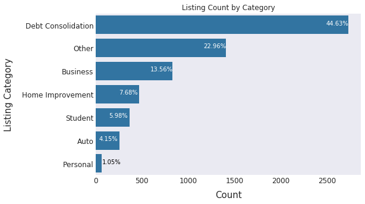

```python
# What are the available Listing cateogories ?
plt.figure(figsize=[ 8, 5])

lc_cnt=df2.LoanCat.value_counts()
lc_pct=df2.LoanCat.value_counts()/df.shape[0]*100

def count (yd, d, ord, cn, pn, var, t1, t2, ylabel, xlabel, title):
    sb.countplot(y=yd, data=d, order=ord.value_counts().index, color=pcolor)

    locs, labels = plt.yticks()
    for loc, label in zip(locs, labels):
            cnt = cn[label.get_text()]
            pct = pn[label.get_text()]
            if pct>=var:
                plt.text(cnt-t1, loc, '{:0.2f}%'.format(pct), ha = 'center', color = 'w')
            else:
                plt.text(cnt+t2, loc, '{:0.2f}%'.format(pct), ha = 'center', color = 'k')
    plt.ylabel(ylabel, labelpad=15, fontsize=15)
    plt.xlabel(xlabel, labelpad=10, fontsize=15)
    plt.title(title)
    plt.xticks(fontsize = 12)
    plt.yticks(fontsize = 12)

count('LoanCat', df2, df2.LoanCat, lc_cnt, lc_pct, 4, 120, 110, 'Listing Category', 'Count', 'Listing Count by Category')
plt.savefig('01lcatCnt.png');
```

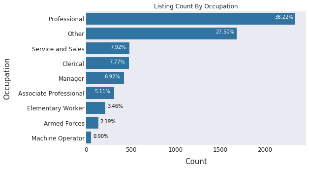

```python
oc_cnt=df.Occupation.value_counts()
oc_pct=df.Occupation.value_counts()/df.shape[0]*100

plt.figure(figsize=[ 8, 5])

count('Occupation', df, df.Occupation, oc_cnt, oc_pct, 4, 130, 110, 'Occupation', 'Count', 'Listing Count By Occupation')
plt.savefig('02occCnt.png');
```

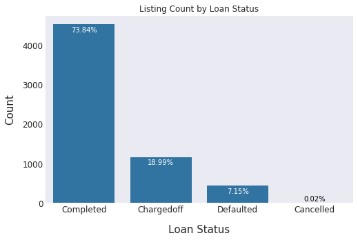

```python
ls_cnt=df.LoanStatus.value_counts()
ls_pct=df.LoanStatus.value_counts()/df.shape[0]*100

plt.figure(figsize=[ 8, 5])
ax = sb.countplot(x='LoanStatus', data=df, order=df.LoanStatus.value_counts().index, color=pcolor)

locs, labels = plt.xticks()
for loc, label in zip(locs, labels):
    cnt = ls_cnt[label.get_text()]
    pct = ls_pct[label.get_text()]
    if pct>5:
        plt.text(loc, cnt-190, '{:0.2f}%'.format(pct), ha = 'center', color = 'w')
    else:
        plt.text(loc, cnt+50, '{:0.2f}%'.format(pct), ha = 'center', color = 'k')
plt.xlabel('Loan Status', labelpad=15, fontsize=15)
plt.ylabel('Count', labelpad=10, fontsize=15)
plt.title('Listing Count by Loan Status')
plt.xticks(fontsize = 12)
plt.yticks(fontsize = 12)
plt.savefig('04lsCnt.png');
```

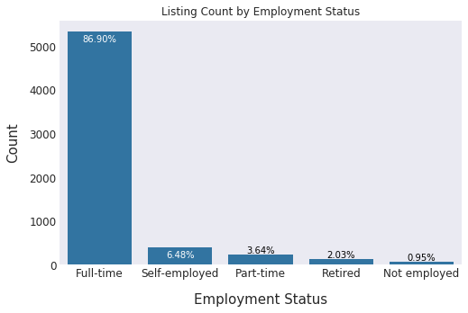

```python
em_cnt=df.EmploymentStatus.value_counts()
em_pct=df.EmploymentStatus.value_counts()/df.shape[0]*100

plt.figure(figsize=[8, 5])
ax = sb.countplot(x='EmploymentStatus',data=df, order=df.EmploymentStatus.value_counts().index,color=pcolor)

locs, labels = plt.xticks()

for loc, label in zip(locs, labels):
    cnt = em_cnt[label.get_text()]
    pct = em_pct[label.get_text()]
    if pct>=6:
        plt.text(loc,cnt-230,'{:0.2f}%'.format(pct),ha='center',
                 color = 'w')
    else:
        plt.text(loc,cnt+40,'{:0.2f}%'.format(pct),ha = 'center',
                 color='k')

plt.xlabel('Employment Status', labelpad=15, fontsize=15)
plt.ylabel('Count', labelpad=10, fontsize=15)
plt.title('Listing Count by Employment Status')
plt.xticks(fontsize = 12)
plt.yticks(fontsize = 12)
plt.savefig('05lsCnt.png');
```

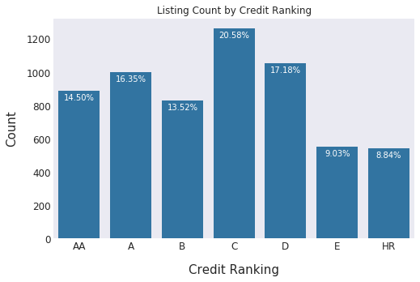

```python
cr_cnt=df.CrRanking.value_counts().loc[[i for i in ['AA','A','B','C','D','E','HR']]]
cr_pct=cr_cnt/df.shape[0]*100

plt.figure(figsize=[8, 5])
ax = sb.countplot(x='CrRanking', data=df2, order=['AA','A','B','C','D','E','HR'],
                  color=pcolor)

locs, labels = plt.xticks()

for loc, label in zip(locs, labels):
    cnt = cr_cnt[label.get_text()]
    pct = cr_pct[label.get_text()]
    if pct>5:
        plt.text(loc,cnt-55,'{:0.2f}%'.format(pct),ha='center',
                 color = 'w')
    else:
        plt.text(loc,cnt,'{:0.2f}%'.format(pct),ha = 'center',
                 color='k')

plt.xlabel('Credit Ranking', labelpad=15, fontsize=15)
plt.ylabel('Count', labelpad=10, fontsize=15)
plt.title('Listing Count by Credit Ranking')
plt.xticks(fontsize = 12)
plt.yticks(fontsize = 12)
plt.savefig('06crCnt.png');
```

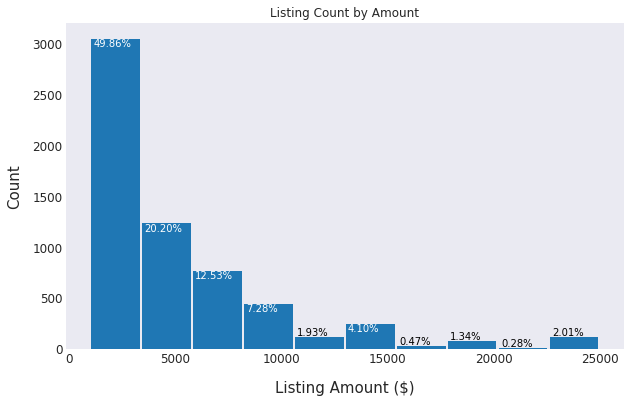

```python
plt.figure(figsize=(10,6))
n,bins,rect = plt.hist(df.LoanOriginalAmount, rwidth = 0.95, color=pcolor)
pts=sum(n)

plt.xlabel('Listing Amount ($)', labelpad=15, fontsize=15)
plt.ylabel('Count', labelpad=10, fontsize=15)
plt.title('Listing Count by Amount');

ax = plt.gca()
for ind in range(len(rect)):
    loc=bins[ind]
    cnt=n[ind]
    pct=int(n[ind])/pts*100
    if pct>3:
        ax.text(loc+150,cnt-80,'{:0.2f}%'.format(pct),
                 color = 'w')
    else:
        ax.text(loc+150,cnt+10,'{:0.2f}%'.format(pct),
                 color='k')

plt.xticks(fontsize = 12)
plt.yticks(fontsize = 12)
plt.savefig('07amtCnt.png');
```

## Bivariate view of selective borrower and loan attributes on listing distributions¶

The correlations between listing frequency, borrower and loan attributes observed in previous visualizations may remain the same, but when another attribute is added, we see differences in the distributions.

When listing amount and credit ranking attributes are viewed together, AA, A and B ratings hold the top 3 spots in listing amount. The same trend of small listing amount prevails, with the median listing amount in each credit ranking remain below $7,500.

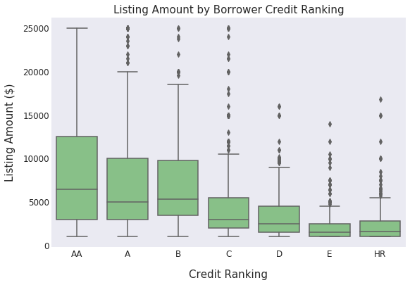

```python
plt.figure(figsize=(9, 6))
ax = sb.boxplot(x='CrRanking', y='LoanOriginalAmount', #hue='CrRankType',
                 data=df2, color=sb.color_palette('Accent', 8)[0], #palette='Set3',
                 order=['AA','A','B','C','D','E','HR'],
                 orient='v');

plt.xlabel('Credit Ranking', labelpad=15, size=15)
plt.ylabel('Listing Amount ($)', labelpad=10, size=15)
plt.title('Listing Amount by Borrower Credit Ranking', size=15);
plt.xticks(size = 12);
plt.yticks(size = 12);
plt.savefig('11amtCrDist.png');
```

## Multivariate view of selective borrower, loan attributes and time series events on listing distributions¶

Comparing listing amount distribution by credit ranking in the pre and post July 2009 periods, we see listing amount distribution across credit rankings is much more pronounced in the pre than in the post July 2009 period.

Comparing listing amount distribution by listing category in the pre and post July 2009 periods, we see post July 2009 period has no listing amount in **Personal category**, the median listing amount in **Debt Consolidation** category remains constant and decreases across **Business**, **Other**, **Home Improvement**, **Student** and **Auto** categories.

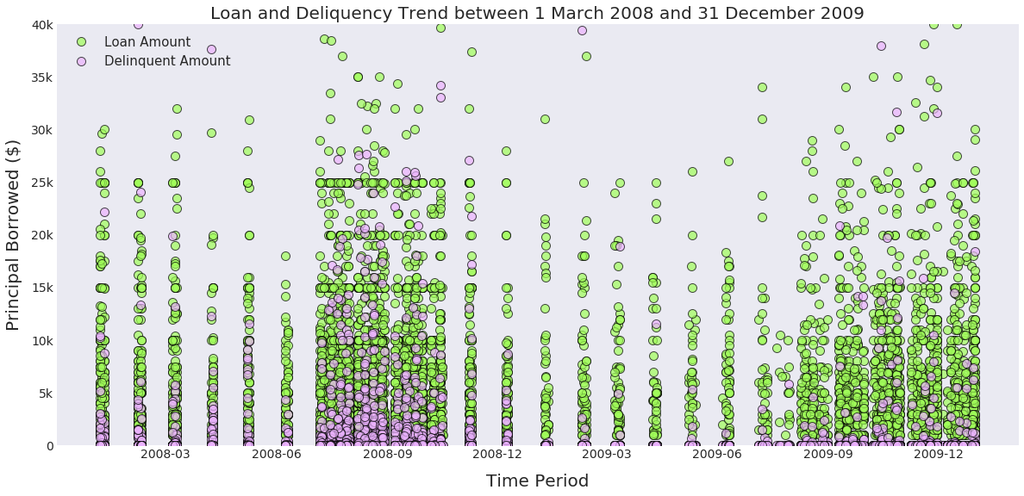

```python
sb.set_style('dark', {'xtick.bottom': True})
period = pd.to_datetime(df.LoanOriginationDate).dt.date
fig, ax = plt.subplots(figsize=(20,9))
plt.plot_date(period, df.ProsperPrincipalBorrowed, color='#A1FE5A',
              marker='o', markeredgecolor='k', linewidth=0.5,
              ms=10, alpha=0.7, label='Loan Amount')
plt.plot_date(period, df.AmountDelinquent, color='#ECB3FF', linewidth=0.5,
              marker='o', markeredgecolor='k',
              ms=10, alpha=0.7, label='Delinquent Amount')

for tick in ax.get_xticklabels():
    tick.set_fontsize(14)

for tick in ax.get_yticklabels():
    tick.set_fontsize(14)

plt.yticks([0,5000,10000,15000,20000,25000,30000,35000,40000],
           ['0','5k','10k','15k','20k','25k','30k','35k','40k'])
plt.ylim((0,40000))
plt.legend(fontsize=15)
plt.xlabel('Time Period', labelpad=15, size=20)
plt.ylabel('Principal Borrowed ($)', labelpad=10, size=20)
plt.title('Loan and Deliquency Trend between 1 March 2008 and 31 December 2009', size=20);
plt.savefig('15amtDelinTimeDist.png');
```

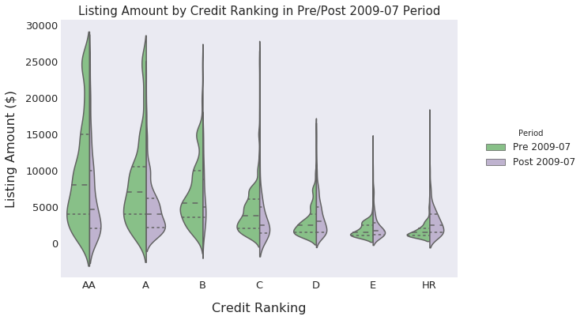

```python
plt.figure(figsize=(9, 6))
ax = sb.violinplot(x='CrRanking', y='LoanOriginalAmount', hue='CrRankType',
                   data=df2, palette='Accent', split=True, inner='quartile',
                   order=['AA','A','B','C','D','E','HR'], scale='count');

plt.legend(title='Period', loc='center left',
           bbox_to_anchor=(1.05, 0.5), fontsize='large');

plt.xlabel('Credit Ranking', labelpad=15, size=16)
plt.ylabel('Listing Amount ($)', labelpad=10, size=16)
plt.title('Listing Amount by Credit Ranking in Pre/Post 2009-07 Period',size=15);
plt.xticks(fontsize = 13);
plt.yticks(fontsize = 13);
plt.savefig('16amtCrPeriodDist.png');
```

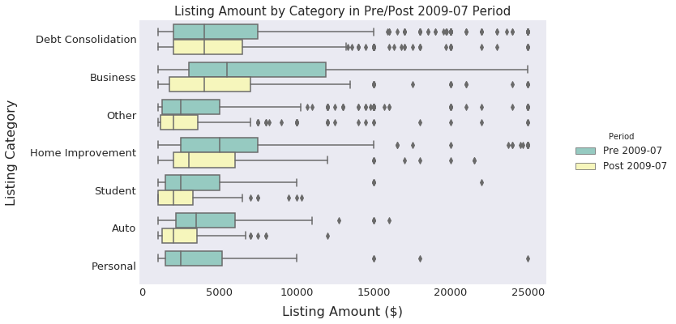

```python
plt.figure(figsize=(9, 6))
ax = sb.boxplot(x='LoanOriginalAmount', y='LoanCat', hue='CrRankType',
                 data=df2, palette='Set3',
                 orient='h');

plt.legend(title='Period', loc='center left',
           bbox_to_anchor=(1.05, 0.5), fontsize='large');

plt.xlabel('Listing Amount ($)', labelpad=10, size=16)
plt.ylabel('Listing Category', labelpad=15, size=16)
plt.title('Listing Amount by Category in Pre/Post 2009-07 Period',size=15);
plt.xticks(fontsize = 13);
plt.yticks(fontsize = 13);
plt.savefig('17amtCatPeriodDist.png');
```

### Generate Slideshow

Once you're ready to generate your slideshow, use the `jupyter nbconvert` command to generate the HTML slide show.

```python
# Use this command if you are running this file in local
!jupyter nbconvert ProsperLoan_slide.ipynb --to slides --post serve --template output-toggle
```